# Unit 4: In Class Exercises

## Announcements

- Submit both your Rmd and the knitted HTML file. It helps us to review what you have done.
- Progress Check 1 coming next week
- A few words on peer evaluations

## Thinking about probabilities

Why learn probability?

- You could learn all the statistical analyses/tests without really understanding probability.

## Binomial probabilities

About 10% of people are left handed.

- What is the probability of exactly 0 left handed people in a *random sample* of 26?
- What is the probability of exactly 1?
- What is the probability of 1 *or more*?

## Binomial probabilities

Probability density functions in R: `dbinom()`, `dnorm()`, `dpois()`, etc.

`dbinom(x, size, prob)`

- `x` = Number of “successes”
- `size` = Sample size
- `prob` = Probability of success for each trial

## Binomial probabilities

What is the probability of *exactly* 0 left handed people in a *sample* of 26?

```r
dbinom(0, 26, prob = 0.1)
```

## Binomial probabilities

What is the probability of *exactly* 0 left handed people in a *sample* of 26?

```r
dbinom(0, 26, prob = 0.1)
```

```
## [1] 0.06461082
```

## Binomial probabilities

What is the probability of exactly 1?

## Binomial probabilities

What is the probability of exactly 1?

```r
dbinom(1, 26, prob = 0.1)
```

```
## [1] 0.1866535
```

## Binomial probabilities

What is the probability of 1 *or more*?

## Binomial probabilities

What is the probability of 1 *or more*?

```r
sum(dbinom(1:26, 26, prob = 0.1))
```

```
## [1] 0.9353892
```

*“or more”* is critical here for hypothesis testing:

- Probability of the observed data or any *more extreme*

## Binomial probabilities for Pr[left] = 0.1

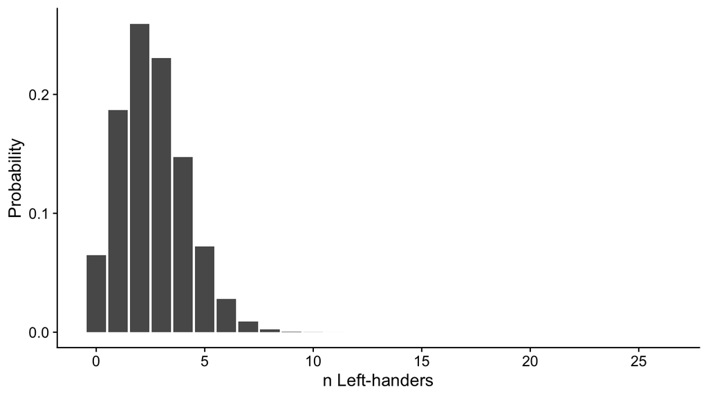

\(n > 8\) have very low probabilities.

## Binomial probabilities for Pr[left] = 0.1

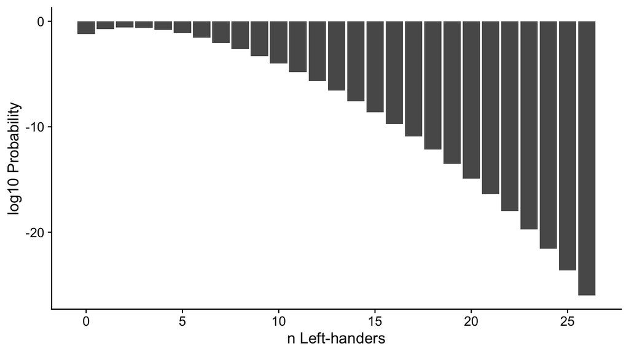

## Powerball

1. 69 balls in one pool: Choose 5
2. 26 in the other pool: Choose 1

Number of winning combinations in pool 1 is the **binomial coefficient**

- the number of unique ordered sequences of successes that yield exactly \(k\) successes from \(n\) trials (“n choose k”).
- the “successes” can happen in any order
- `choose(n, k)`

\[\left({n\atop k}\right)=\frac{n!}{k!\left(n - k\right)!}\]

## Powerball

1. 69 balls in one pool: Choose 5
2. 26 in the other pool: Choose 1

```r
choose(69, 5)
```

```
## [1] 11238513
```

```r
choose(26, 1)
```

```
## [1] 26
```

## Powerball

5 successes from 69 chances \(\times\) 1 success from 26 chances.

```r
choose(69, 5) * choose(26, 1)
```

```
## [1] 292201338
```

What if the order had to be correct as well?

## Breast cancer screening

Approximately correct numbers:

1. 1 in 100 women in the age range 40-50 have breast cancer
2. 80% with cancer have a positive mammogram (true positives)
3. 10% without cancer have a positive mammogram (false positives)

What is the probability of a randomly sampled woman having breast cancer, given a positive test?

## Breast cancer screening

\[Pr[C|T] = \frac{Pr[T|C] \times Pr[C]}{Pr[T]}\]

- \(Pr[T|C] = 0.8\)
- \(Pr[C] = 1/100 = 0.01\)
- \(Pr[T]\) = ???

## Breast cancer screening

\[Pr[C|T] = \frac{Pr[T|C] \times Pr[C]}{Pr[T]}\]

- \(Pr[T|C] = 0.8\)
- \(Pr[C] = 1/100 = 0.01\)
- \(Pr[T] = (0.8 \times 0.01) + (0.1 \times 0.99)\)

## Breast cancer screening

\[Pr[C|T] = \frac{Pr[T|C] \times Pr[C]}{Pr[T]}\]

- \(Pr[T|C] = 0.8\)
- \(Pr[C] = 0.01\)
- \(Pr[T] = (0.8 \times 0.01) + (0.1 \times 0.99)\)

```r
(0.8 * 0.01) / ((0.8 * 0.01) + (0.1 * 0.99))
```

```
## [1] 0.07476636
```

## Breast cancer screening

Approximately correct numbers:

1. 1 in 100 women in the age range 40-50 have breast cancer
2. 20% with cancer have a negative mammogram (false negative)
3. 90% without cancer have a negative mammogram (true negative)

What is the probability of a randomly sampled woman having breast cancer, given a negative test?

## Breast cancer screening

\[Pr[C|N] = \frac{False~Negatives}{False~Negatives + True~Negatives}\]

\[Pr[C|N] = \frac{Pr[N|C] \times Pr[C]}{Pr[N]}\]

## Breast cancer screening

- 100 women
- 1 has cancer, 99 do not
- How many overall will get a negative test?

With cancer: 1 * 0.2 = 0.2

Without cancer: 99 * 0.9 = 89.1

Total negative tests: 0.2 + 89.1 = 89.3

Probability of having cancer, given negative test:

```r
0.2/89.3
```

```
## [1] 0.002239642
```